# Final project - part 2

Klemen Hovnik and Manca Strgar

# 1 Fitting exponential function

First we need to import our data from the file `SeverityCensoring` into R. The file contains 9062 claims, with columns representing policy id, claim id, rc (iz claim is censored - number or uncensored - value NA ), deductible (always 100) and the claim amount.

|  | policyId | claimId | rc | deductible | claimAmount |
| --- | --- | --- | --- | --- | --- |
| 3 | 600003 | 900003 | 41639 | 100 | 41639 |
| 50 | 600045 | 900050 | NA | 100 | 16965 |
| 51 | 600045 | 900051 | NA | 100 | 363 |
| 58 | 600052 | 900058 | 5949 | 100 | 5949 |
| 77 | 600071 | 900077 | NA | 100 | 148 |

Before we start fitting exponential distribution to our data we will modify our rc column, so that it is a logical colum (indicator), where TRUE means the claim is censores and FALSE means that the claim is not censored. This is how we do this:

```r
Severity$rc <- !is.na(Severity$rc)
```

Now we can finally fit exponential distribution to our model.We will compute negative log-likelihood function, taking trucation and censoring into account. We will do this with the help of `dexp` and `pexp` function that represent density and distribution functions of exponential distribution. As our paramether $\lambda > 0$ we use $\lambda = e^{\beta}$ and now it can take all values.

```r
claimAmount <- Severity$claimAmount
rc <- Severity$rc
deductible <- Severity$deductible

exp.negloglikelihood <- function(par)
  {lambda <- exp(par)
  -sum(dexp(claimAmount[!rc],lambda,log=T)) - #here we take values of claimAmount if rc false
    sum(pexp(claimAmount[rc],lambda,log.p=T,lower.tail=F)) + #claimamount if rc true
    sum(pexp(deductible,lambda,log.p=T,lower.tail=F)) #adds deductible
}
```

To get the initial estimation of our parameter, we use the moment estimation. As we know
$$E(X) = \frac1\lambda$$
and from here we get that
$$\lambda = \frac1{m_1}.$$
Where $m_1$ is first moment derived from our data. Now we can fit exponential distribution and we get the MLE estimation of $\lambda$:

```
## [1] 0.0004694256
```

The value of AIC is equal to:

```
## [1] 127986.6
```

# 2 fitting other distributions

Now for the second pard we need to also fit three other distributions to our data: lognormal, inverse Gaussian and Burr distribution

## 2.1 Fitting lognormal distribution

We repeat our process from above. But we need different inital estimations for our two parameters $\mu$ and $\sigma^2$. We need to use the first and the second moments:
$$E(X) = e^{ \mu + \frac{\sigma^2}{2}}$$
$$E(X^2) = e^{2\mu + 2\sigma^2}$$
Now we get first and the second moment from our data and from that our estimations. We fit the model and get our estimates for $\mu$ and $\sigma^2$:

```
## [1] 6.154313 1.955911
```

And AIC for this fit is:

```
## [1] 121207.2
```

## 2.2 Fitting inverse Gaussian distribution

Here our first two moments, that are used for the initial estimation, are equal to:
$$E(X) = \mu$$
$$E(X^2) = \mu^2 + \frac{\mu^3}{\theta}$$
Whit this we get our estiamtions for $\mu$ and $\theta$:

```
## [1] 5512.4128  427.6825
```

AIC for inverse Gaussian fit is:

```
## [1] 120651.7
```

## 2.3 Fitting Burr distribution

Here we have three paramethers, so we need first three moments, for initial estimation.
$$E(X) = \frac{\theta * \Gamma(1+ \frac{1}{\gamma})* \Gamma(\alpha-\frac{1}{\gamma})}{\Gamma(\alpha)}$$
$$E(X^2) = \frac{\theta^2 * \Gamma(1+ \frac{2}{\gamma})* \Gamma(\alpha-\frac{2}{\gamma})}{\Gamma(\alpha)}$$
$$E(X^3) = \frac{\theta^3 * \Gamma(1+ \frac{3}{\gamma})* \Gamma(\alpha-\frac{3}{\gamma})}{\Gamma(\alpha)}$$
Whit this we get our estiamtions for $\alpha$, $\theta$ and $\gamma$:

```
## [1] 0.163914852 3.631583521 0.004719882
```

Corresponding AIC is:

```
## [1] 119870.7
```

# 3 Fitting Erlang mixture distribution

Here we use the felp of EM algorithm for Erlang mixtures which we source from file `EM_MixedErlang`. We need to define loss and nrc vector so that they meet the conditions form the insutructions. This is how we did this:

```r
loss <- claimAmount ;
nrc <- claimAmount
for (i in 1:9062) {
  if (rc[i] == TRUE){
    nrc[i] <- NA
  }
}
```

Here are the MLE estimations for Erlang mixture distribution:

```
## M =  5 ,  AIC  =  119843.4 , shape =  1 6 14 27 96
##  theta =  612.2609 , alpha =  0.8228129 0.04624449 0.01072555 0.02000244 0.1002147
```

```
## $alpha
## [1] 0.82281285 0.04624449 0.01072555 0.02000244 0.10021467
##
## $beta
## [1] 0.79773427 0.05278980 0.01224362 0.02283353 0.11439878
##
## $shape
## [1]  1  6 14 27 96
##
## $theta
## [1] 612.2609
##
## $loglikelihood
## [1] -59911.69
##
## $AIC
## [1] 119843.4
##
## $BIC
## [1] 119914.5
##
## $M
## [1] 5
##
## $M_initial
## [1] 5
##
## $s
## [1] 3
```

# 4 Plotting the Kaplan-Meier estimate of the survival function

Here we need to define three vectors: deds, loss and full and then plot the fit. We do this like this:

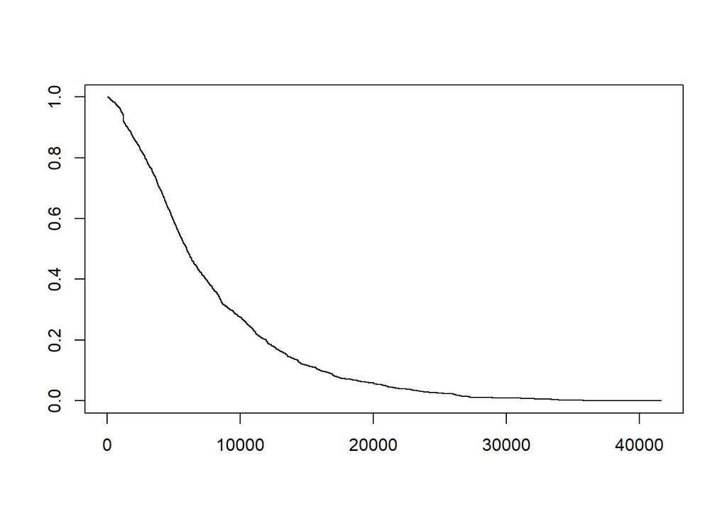

```r
deds <- deductible ; loss <- claimAmount ;
full <- rc
for (i in 1:9062) {
  if (rc[i] == TRUE){
    full[i] == FALSE
  }else{full[i] == TRUE}
}


fit <- survfit(Surv(deds, loss, full) ~ 1)
plot(fit, mark.time=F, conf.int=F)
```

# 5 Plots

Now we will plot all the survival functions for all the different distributions onto one graph, so that we can compare them. The graph looks like this:

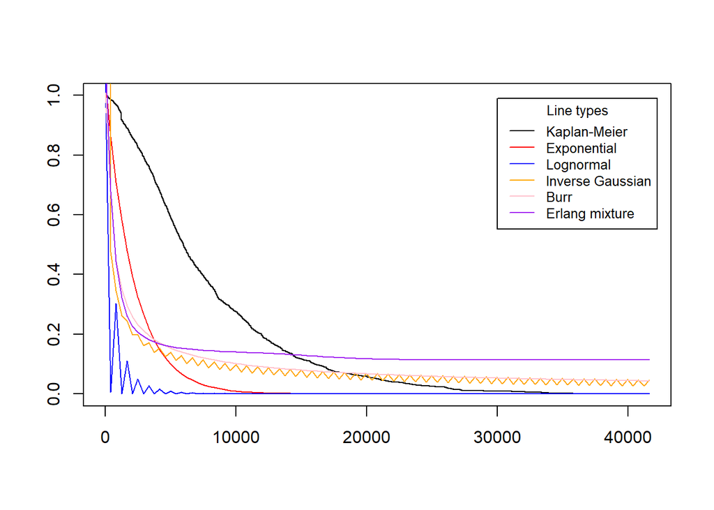

The model that seems closest to Kaplan-Meier estimate is the Burr model in our opinion.

# 6 Comparison of AIC values

The Akaike information criterion (AIC) is an estimator of prediction error and thereby relative quality of statistical models for a given set of data. Given a collection of models for the data, AIC estimates the quality of each model, relative to each of the other models. Thus, AIC provides a means for model selection. Given a set of candidate models for the data, the preferred model is the one with the minimum AIC value. So lets again write down AIC values for our models:

```
##                       AIC
## Erlang mixture   119843.4
## Burr             119870.7
## Inverse Gaussian 120651.7
## Lognormal        121207.2
## Exponential      127986.6
```

As we can see that the best choice of model is the one with Exlang mixture distribution. The most inappropriate among this models is the one with Exponential distribution , according to the AIC parameter. In exercise 5 we thought that the Burr distribution fits best to the Kaplan-Meier estimate, but AIC parameter tells us that Exlang mixture model is the best, so our anwser is not consistent.